# Kalkunte-Nikhith-HW-3

# Challenge 1

```r
f = "https://raw.githubusercontent.com/difiore/ADA-datasets/master/KamilarAndCooperData.csv"
d = read_csv(f)
```

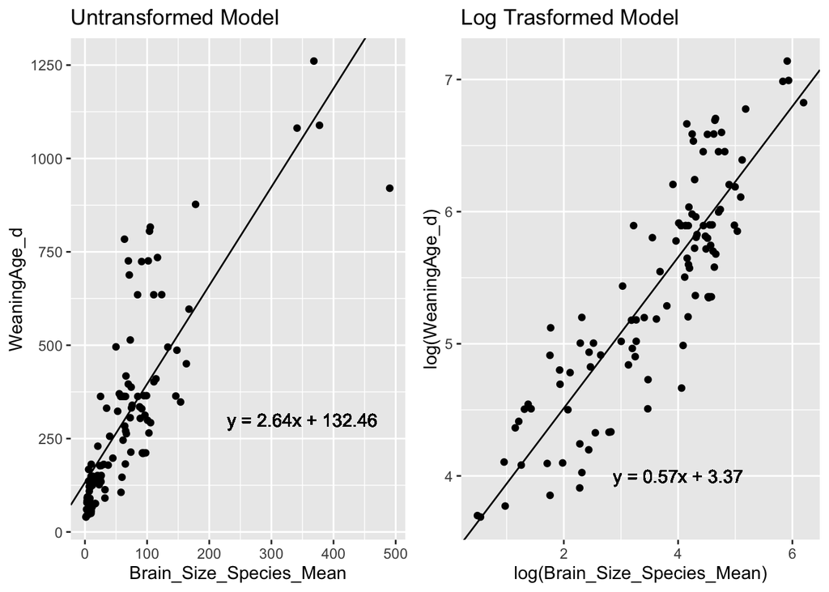

```r
m = lm(WeaningAge_d~Brain_Size_Species_Mean, data = d)
logM = lm(log(WeaningAge_d)~log(Brain_Size_Species_Mean), data = d)


g  = ggplot(data = d, aes(x = Brain_Size_Species_Mean, y = WeaningAge_d)) +
  geom_point() +
  geom_abline(slope = m$coefficients[2],intercept = m$coefficients[1])+
  ggtitle("Untransformed Model") + geom_text(x = 350, y = 300, label = paste0("y = ",round(m$coefficients[2],digits = 2),"x + ",round(m$coefficients[1],digits = 2)))

gLOG = ggplot(data = d, aes(x = log(Brain_Size_Species_Mean), y = log(WeaningAge_d))) +
  geom_point() +
  geom_abline(slope = logM$coefficients[2],intercept = logM$coefficients[1])+
  ggtitle("Log Trasformed Model") + geom_text(x = 4, y = 4, label = paste0("y = ",round(logM$coefficients[2],digits = 2),"x + ",round(logM$coefficients[1],digits = 2)))

plot_grid(g,gLOG)
```

```r
alpha = .1
(m.summary = tidy(m, conf.int = TRUE, conf.level = 1-alpha))
```

```
## # A tibble: 2 x 7
##   term                  estimate std.error statistic  p.value conf.low conf.high
##   <chr>                    <dbl>     <dbl>     <dbl>    <dbl>    <dbl>     <dbl>
## 1 (Intercept)             132.      19.2        6.91 3.69e-10   101.      164.
## 2 Brain_Size_Species_M…     2.64     0.185     14.3  1.59e-26     2.33      2.94
```

```r
(mLog.summary = tidy(logM, conf.int = TRUE, conf.level = 1-alpha))
```

```
## # A tibble: 2 x 7
##   term                  estimate std.error statistic  p.value conf.low conf.high
##   <chr>                    <dbl>     <dbl>     <dbl>    <dbl>    <dbl>     <dbl>
## 1 (Intercept)              3.37     0.117       28.9 2.53e-52    3.18      3.56
## 2 log(Brain_Size_Speci…    0.571    0.0306      18.7 1.99e-35    0.520     0.622
```

For the untransformed model, B1 point estimate is 2.64, the p value us 1.59e-26 indicating a rejection of the null hypothesis, and the 90% CI is [2.33,2.94]

For the transformed model, B1 point estimate is 0.57, the p value us 1.99e-35 indicating a rejection of the null hypothesis, and the 90% CI is [0.52,0.62]

```r
xvals = data.frame(Brain_Size_Species_Mean = d$Brain_Size_Species_Mean)
ci.m = tibble(x = xvals$Brain_Size_Species_Mean,
              lower = confint(m, level  = .90)[2,1]*xvals$Brain_Size_Species_Mean + confint(m,level  = .90)[1,1],
              upper = confint(m, level  = .90)[2,2]*xvals$Brain_Size_Species_Mean + confint(m,level  = .90)[1,2])

ci.mLog = tibble(x = log(xvals$Brain_Size_Species_Mean),
              lower = confint(logM, level  = .90)[2,1]*log(xvals$Brain_Size_Species_Mean) + confint(logM,level  = .90)[1,1],
              upper = confint(logM, level  = .90)[2,2]*log(xvals$Brain_Size_Species_Mean) + confint(logM,level  = .90)[1,2])


yPredict.m = as_tibble(predict(m, newdata = xvals, interval = 'prediction'))
yPredict.mLog = as_tibble(predict(logM, newdata = log(xvals), interval = 'prediction'))
yPredict.m$x = xvals$Brain_Size_Species_Mean
yPredict.mLog$x = log(xvals$Brain_Size_Species_Mean)
h.m = g +
  geom_line(data = ci.m, aes(x = x, y = lower, color = "red")) +
  geom_line(data = ci.m, aes(x = x, y = upper, color = "red")) +
  geom_line(data = yPredict.m, aes(x=x,y=lwr, color = "blue")) +
  geom_line(data = yPredict.m, aes(x=x,y=upr, color = "blue")) +
  scale_colour_manual(name = '', values =c('red'='red','blue'='blue'), labels = c('90% CI','Prediction Int.'))


h.mLog = gLOG +
  geom_line(data = ci.mLog, aes(x = x, y = lower, color = "red")) +
  geom_line(data = ci.mLog, aes(x = x, y = upper, color = "red")) +
  geom_line(data = yPredict.mLog, aes(x=x,y=lwr, color = "blue")) +
  geom_line(data = yPredict.mLog, aes(x=x,y=upr, color = "blue")) +
  scale_colour_manual(name = '', values =c('red'='red','blue'='blue'), labels = c('90% CI','Prediction Int.'))

(predict(m, newdata = data.frame(Brain_Size_Species_Mean = 750), interval = 'prediction'))
```

```
##        fit      lwr      upr
## 1 2110.294 1720.247 2500.341
```

```r
(predict(logM, newdata = data.frame(Brain_Size_Species_Mean = 750), interval = 'prediction'))
```

```
##        fit     lwr      upr
## 1 7.150967 6.31244 7.989495
```

The transformed model looks to represent a true minimization residuals and a normal distribution of data points at all values of the explanatory variable plotted. This means the model created will have astronger fit with the data.

# Challenge 2

```r
alpha <- 0.05
m2 = lm(data = d, log(MeanGroupSize)~log(Body_mass_female_mean))
tidy(m2,conf.int = TRUE, conf.level = 1 - alpha)
```

```
## # A tibble: 2 x 7
##   term                  estimate std.error statistic  p.value conf.low conf.high
##   <chr>                    <dbl>     <dbl>     <dbl>    <dbl>    <dbl>     <dbl>
## 1 (Intercept)             -1.78     0.438      -4.06 8.06e- 5   -2.64     -0.912
## 2 log(Body_mass_female…    0.506    0.0556      9.10 8.08e-16    0.396     0.616
```

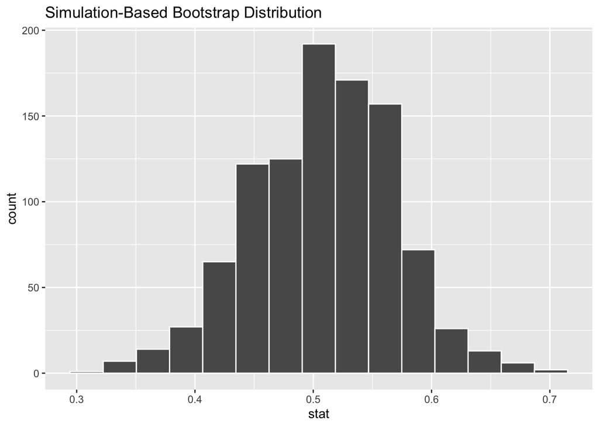

```r
d$logMeanGroupSize = log(d$MeanGroupSize)
d$logBody_mass_female_mean = log(d$Body_mass_female_mean)
boot.slope =  d %>%
  specify(logMeanGroupSize~logBody_mass_female_mean) %>%
  generate(reps = 1000, type = "bootstrap") %>%
  calculate(stat = "slope")
boot.intercept = tibble(replicate = boot.slope$replicate, stat = mean(d$logMeanGroupSize,na.rm=TRUE) - mean(d$logBody_mass_female_mean, na.rm=TRUE)*boot.slope$stat)

visualize(boot.slope)
```

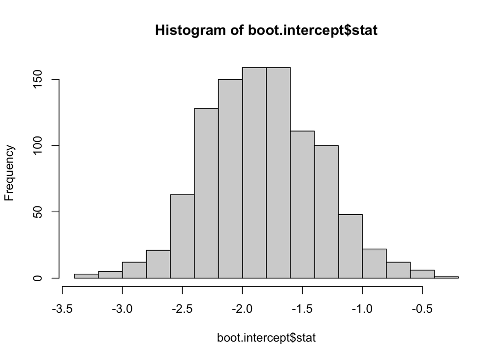

```r
hist(boot.intercept$stat)
```

```r
confidence_level <- 1 - alpha
p_lower <- alpha / 2
p_upper <- 1 - (alpha / 2)


boot.slope.summary <- boot.slope %>%
  summarize(
    estimate = mean(stat),
    std.error = sd(stat),
    boot.lower = quantile(stat, p_lower),
    boot.upper = quantile(stat, p_upper)
  )

boot.intercept.summary <- boot.intercept %>%
  summarize(
    estimate = mean(stat),
    std.error = sd(stat),
    boot.lower = quantile(stat, p_lower),
    boot.upper = quantile(stat, p_upper)
  )
```

The SE’s estimated via the bootstrap sampling distribution compare well to those estimated via the lm() function. For the estimate of slope, lm() reported a SE of 0.05563, while the bootstrapped estimated reported an SE of 0.06271. For the estimate of the intercept, lm() reported a SE of 0.43752, and the bootstrapped is 0.4857971. These values are relatively close in magnitude.

The CI’s estimated via the bootstrap sampling distribution compare well to those estimated via the lm() function. For the estimate of slope, lm() reported a CI of [0.396, 0.616], while the bootstrapped estimated reported an CI of [0.384, 0.634] For the estimate of the intercept, lm() reported a CI of [-2.642, -0.912], and the bootstrapped is [-2.814,-0.877]. Though there is more variace seen here than the Se values, I believe these values are comparable.

# Challenge 3

```r
boot_lm = function(d,model,conf.level = 0.95,reps=1000){
 alpha = 1-conf.level
p_lower <- alpha / 2
p_upper <- 1 - (alpha / 2)

f = as.formula(model)
m = lm(data = d,f)
true = tidy(m,conf.int = TRUE, conf.level = 1 - alpha)[,c(2,3,6,7)]

boot.slope =  d %>%
  specify(f) %>%
  generate(reps = reps, type = "bootstrap") %>%
  calculate(stat = "slope")

b = d %>%
  specify(f) %>%
  generate(reps = 1000, type = "bootstrap")
x = colnames(b)[3]
y = colnames(b)[2]
b.1 = b %>%
  group_by(replicate) %>%
  summarise_at(
    .cols = c(x,y),
    .funs = c(mean = "mean")
  )

boot.intercept = tibble(replicate = boot.slope$replicate, stat = unlist(b.1[,3] - b.1[,2]*boot.slope$stat))

boot.intercept.summary <- boot.intercept %>%
  summarize(
    estimate = mean(stat),
    std.error = sd(stat),
    conf.low = quantile(stat, p_lower),
    conf.high = quantile(stat, p_upper)
  )

boot.slope.summary <- boot.slope %>%
  summarize(
    estimate = mean(stat),
    std.error = sd(stat),
    conf.low = quantile(stat, p_lower),
    conf.high = quantile(stat, p_upper)
  )

data = rbind(c("Original B1",true[2,]),
             c("Original B0",true[1,]),
             c("Bootstrapped B1",boot.slope.summary),
             c("Bootstrapped B0",boot.intercept.summary))
return(data)
}

d$logDayLength_km = log(d$DayLength_km)

(M1 = boot_lm(d,model = "logMeanGroupSize ~ logBody_mass_female_mean"))
```

```
## `.cols` has been renamed and is deprecated, please use `.vars`
```

```
##                        estimate  std.error  conf.low  conf.high
## [1,] "Original B1"     0.5062813 0.05562507 0.3963075 0.616255
## [2,] "Original B0"     -1.777258 0.4375157  -2.64225  -0.9122659
## [3,] "Bootstrapped B1" 0.5051868 0.06375564 0.3842695 0.6263394
## [4,] "Bootstrapped B0" -1.770238 0.5014183  -2.745202 -0.8252678
```

```r
(M2 = boot_lm(d,model = "logDayLength_km ~ logBody_mass_female_mean"))
```

```
## `.cols` has been renamed and is deprecated, please use `.vars`
```

```
##                        estimate   std.error  conf.low    conf.high
## [1,] "Original B1"     0.0389422  0.0566739  -0.07347022 0.1513546
## [2,] "Original B0"     -0.1427624 0.4650068  -1.065101   0.7795764
## [3,] "Bootstrapped B1" 0.0423032  0.05967842 -0.07465872 0.1616034
## [4,] "Bootstrapped B0" -0.1688989 0.486826   -1.145726   0.7925306
```

```r
#(M3 = boot_lm(d,model = "logDayLength_km ~ logBody_mass_female_mean + logMeanGroupSize"))
```

I wasn’t able to get the multiple regressions working in my function as written.